# Plotting expression levels

Jared J. Homola

4/23/2020

This document provides ideas for plotting gene/transcript expression levels. A few notes…

1. Amanda and I are thinking of the manuscript’s analyses in two broad categories: a) Differential expression analyses and b) Analyses of a priori listed genes of interest. This document is organized by those categories.
2. Each “scenario” given below is an example of an instance where we will likely want to plot data.
3. The example given for a differential expression analysis is for the day 1 control, low, moderate, and high shedding birds at the transcript level.
4. When plotting expression levels for each of these, we could stick to our low-moderate-high shedding level categories or use a continuous axis of virus titer. If we use a continuous axis, we could highlight breakpoints along it where we propose low, moderate, and high levels exist so it could still be tied back to the DE analyses, but that is not shown here.
5. For DE plots, we can attach a p-value from the DE analysis to these plots. For analysis of a priori genes, we do not do a statistically test at this point, instead just looking at the overall pattern.

## Differential expression analyses

### DE plotting scenario 1:

### Single transcripts of interest from the DE results with boxplots

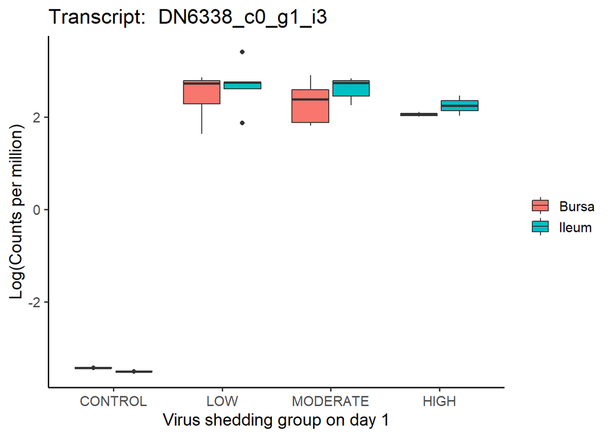

### Single transcripts of interest from the DE results with scatterplots

The line is drawn as a Loess fuction and gray area shows 95% confidence intervals.

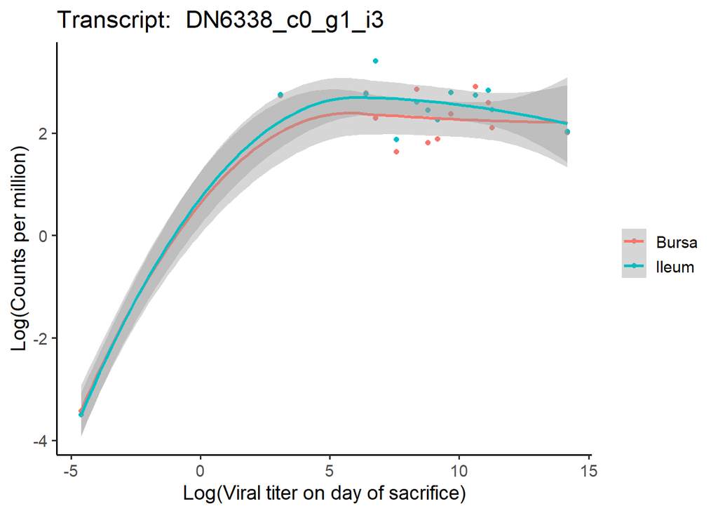

### DE plotting scenario 2:

### Heatmaps to reveal gene/transcript and sample clusters

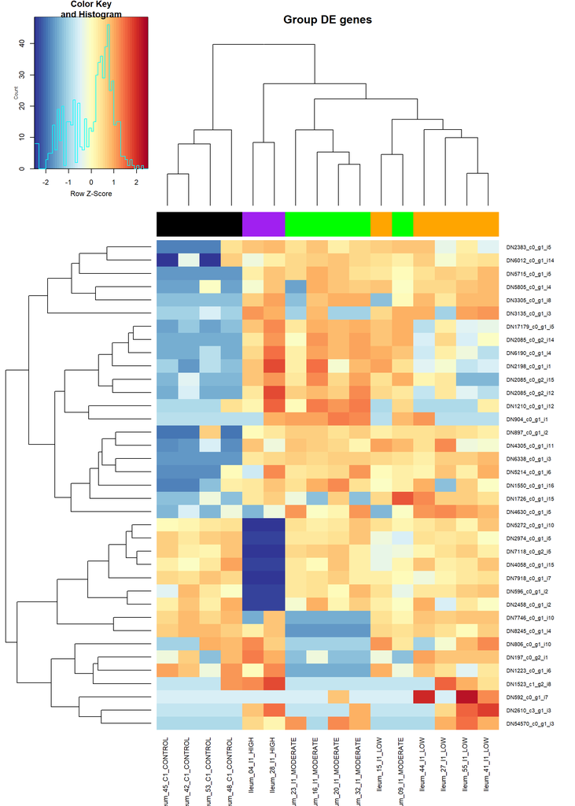

### DE plotting scenario 3:

### Plotting transcripts/genes that cluster together

#### Step 1: Identify clusters

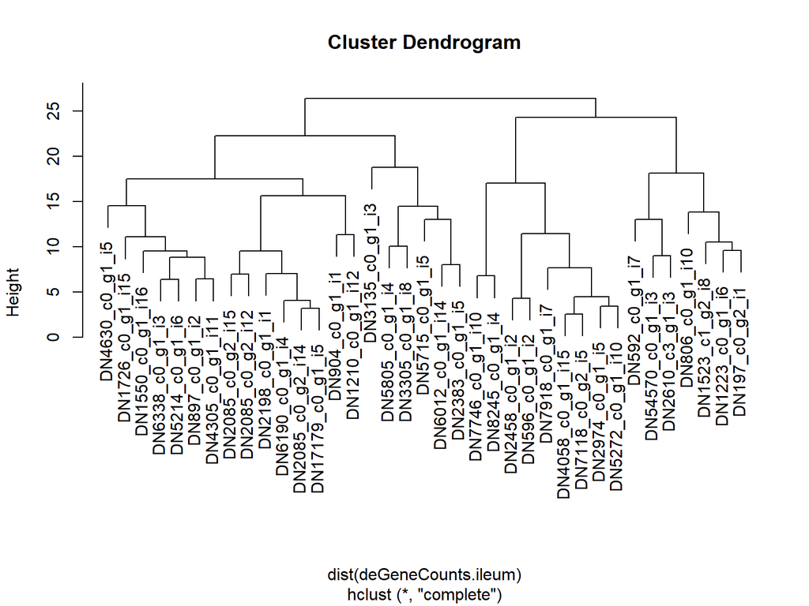

#### Step 2: Plot expression of a cluster

Gray lines are individual transcripts and the blue line is their mean value. This is for just one tissue type- the one that is used to build heatmaps and establish groupings (ileum in this case).

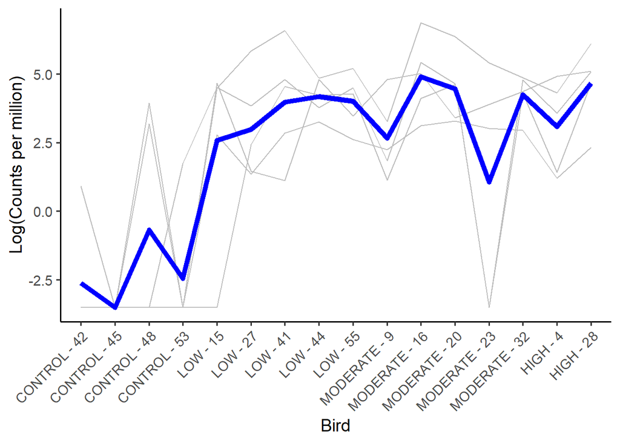

### Analysis of priori genes plotting scenario 1

### Plotting all transcripts/genes with a given annotation: Categorical x axis, line plot

This example is for all genes with a SwissProt annotation for MX protein encoding genes. Note that these plots put all associated transcripts on one figure. They could also be broken apart into large multi-panel figures if preferable.

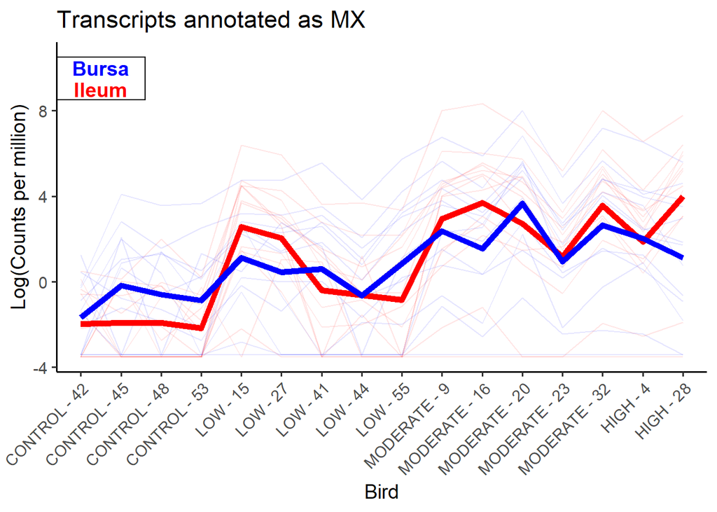

### Analysis of priori genes plotting scenario 1

### Plotting all transcripts/genes with a given annotation: Continuous x axis, scatterplot with Loess